REVIEW

Open Access

Safety and efficacy of cell therapies in

pediatric heart disease: a systematic review

and meta-analysis

John Martinez<sup>1</sup>†, Sarah Zoretic<sup>1</sup>†, Axel Moreira<sup>1,2</sup>and Alvaro Moreira<sup>1,3*</sup>

Abstract

Background: Adult clinical trials have reported safety and the therapeutic potential of stem cells for cardiac

disease. These observations have now translated to the pediatric arena. We conducted a meta-analysis to assess

safety and efficacy of cell-based therapies in animal and human studies of pediatric heart disease.

Methods and results: A literature search was conducted to examine the effects of cell-based therapies on: (i)

safety and (ii) cardiac function. In total, 18 pre-clinical and 13 human studies were included. Pre-clinical: right

ventricular dysfunction was the most common animal model (80%). Cardiac-derived (28%) and umbilical cord blood

(24%) cells were delivered intravenously (36%) or intramyocardially (35%). Mortality was similar between cell-based

and control groups (OR 0.94; 95% CI 0.05, 17.41). Cell-based treatments preserved ejection fraction by 6.9% (p <

0.01), while intramyocardial at a dose of 1–10 M cells/kg optimized ejection fraction. Clinical: single ventricle

Administration of cell-based therapies improved ejection fraction (MD 4.84; 95% CI 1.62, 8.07; p < 0.01).

Conclusions: In this meta-analysis, cell-based therapies were safe and improved specific measures of cardiac

function. Implications from this review may provide methodologic recommendations (source, dose, route, timing)

for future clinical trials. Of note, many of the results described in this study pattern those seen in adult stem cell

reviews and meta-analyses.

Keywords: Regenerative medicine, Stem cells, Cardiology, Pediatric, Heart

Background

Less than one half of patients diagnosed with critical

congenital heart disease (CCHD) will survive into adult-

hood [1]. CCHD represents a group of cardiac condi-

tions requiring surgical intervention within the first year

of life and affects ~ 1 in every 500 births in the USA

annually [2, 3]. Although surgical advancements have

prolonged survival, many patients will develop cardiac

morbidities that will eventually necessitate heart trans-

plantation. As pediatric donors are scarce, novel therap-

ies are warranted to preserve cardiac function, reduce

morbidity, and improve overall outcomes.

Literature in adults suggests regenerative therapies are

safe and efficacious in patients with myocardial infarc-

tion, heart failure, and dilated cardiomyopathy [4–7].

These findings have prompted further investigation into

the use of cell-based/derived therapies (CBT) in CCHD.

Animal models mimicking CCHD have consistently

demonstrated that stem/stromal cell therapies are safe

[figure not shown]

* Correspondence: MoreiraA@uthscsa.edu

†John Martinez and Sarah Zoretic contributed equally as co-first authors.

1Department of Pediatrics, University of Texas Health San Antonio, San

Antonio, TX 77229, USA

3Department of Pediatrics, UT Health San Antonio, 7703 Floyd Curl Drive, MC

7812, San Antonio, TX 78229, USA

Full list of author information is available at the end of the article

[figure not shown]

Martinez et al. Stem Cell Research & Therapy (2020) 11:272

https://doi.org/10.1186/s13287-020-01764-x

and effective [8, 9]. Currently, early phase clinical trials

utilizing regenerative cells for CCHD and other pediatric

heart conditions are ongoing.

We conducted a systematic review and meta-analysis

of pre-clinical and clinical studies to test the hypothesis

that cell-based/derived therapies for congenital or ac-

quired pediatric heart disease are safe and effective. In

doing so, we hope to identify the variables that will have

the greatest clinical impact and identify knowledge gaps

that need to be addressed in future studies. Implications

from this review may provide recommendations and

evidence-based results for future human trials.

Methods

The protocol for this review was submitted and regis-

tered with PROSPERO international database of system-

atic

reviews

and

meta-analysis

(Supplemental

1):

registration number: CRD42019149559. Our methods

adhere to the guidelines established by the Systematic

Review Centre for Laboratory Animal Experimentation

(SYRCLE) and are described in Supplemental 2.

Literature search

Literature search was performed using PUBMED, Sco-

pus, ScienceDirect, and Web of Science through Sep-

tember 3, 2019. Search terms included synonyms for

“stem cell,” “regenerative therapy,” and “congenital heart

disease” (full search terms available in Supplemental 3).

Restrictions to the search were not placed on dates or

languages. Reference lists of relevant reviews and in-

cluded studies were examined.

After removal of duplicates, papers were screened by

title and abstract and then evaluated for eligibility by

full-text review performed by two independent investiga-

tors (JM, SZ). Differences of opinion in either phase

were resolved by a third investigator (AM). Individual

searches of reference lists of included studies were per-

formed in an attempt to obtain additional studies for

inclusion.

Inclusion and exclusion criteria

Interventional and observational human studies asses-

sing the safety and efficacy of CBT in congenital/

pediatric heart disease were included. We defined cell-

based therapies to include the following: mesenchymal

stromal cells, embryonic cells, multipotent cells, indu-

cible pluripotent cells, progenitor cells, hematopoietic

cells, umbilical cord blood cells, c-kit+ cells, and cell de-

rived as the secretome, exosomes, microRNA, microvesi-

cles, and extracellular vesicles. Due to the paucity of

human studies evaluating stem cell use in congenital

heart disease, case reports were included. Studies includ-

ing adult patients with a history of congenital heart dis-

ease (i.e., hypoplastic left heart syndrome (HLHS))

receiving CBT were included, whereas studies describing

use of regenerative therapies in adult patients with other

cardiac

illnesses

(i.e.,

myocardial

infarctions)

were

excluded.

Pre-clinical studies were included if they reported the

effect of CBT on validated in vivo animal models of con-

genital heart disease (e.g., RV overload). The uses of

CBT were included regardless of dosage, timing, fre-

quency, and source. Animal models of adult heart dis-

ease (myocardial infarction/ischemia) or healthy hearts

were excluded.

Primary endpoints

Our primary endpoints were safety and efficacy of cell-

based/derived therapies in pre-clinical or clinical studies

of both congenital and pediatric heart disease. Safety

was defined as either mortality or the occurrence of ad-

verse events (e.g., fever, rash, infection, hemodynamic in-

stability, arrhythmia) associated with administration of

CBT. Efficacy included measures of cardiac function:

right ventricular ejection fraction, left ventricular ejec-

tion fraction (RVEF, LVEF), end diastolic or end systolic

volumes (EDV, ESV), fractional area change (FAC), frac-

tional shortening (FS), and tricuspid annular plane sys-

tolic excursion (TAPSE).

Data extraction

Data was collected independently by two investigators

(JM, SZ) and compared for accuracy. A third investigator

(AM) assisted in resolution of difference of opinion. Ex-

tracted data included general study design (disease

model, clinical trial phase, objective, sample size, inclu-

sion/exclusion criteria), animal characteristics (species,

age, gender, immune status), intervention characteristics

(cell type, tissue source, dose, delivery, timing, fre-

quency), and bibliographical information (author, year,

funding, title, language, contact author email, journal)

along with any measures related to our primary outcome

as defined above. Study data was obtained from text,

graphs, and plots. WebPlot digitizer was used to collect

values from figures when not explicitly stated in the text.

For all studies where dosages were not reported in a

cells/kg basis, the mean weight reported was used to cal-

culate a mean dose of cells/kg. When an absolute cell

count was provided, the mean weight (if present) was

used to obtain a cells/kg dose. When two separate dos-

ages were reported, mean dose/kg were obtained. When

no weight was reported, absolute cell number was used.

Such cases are denoted by an asterisk in Table 1.

Additional cell-based/derived characteristics obtained

included passage number, whether cells were self-

isolated or purchased along with any positive surface

markers noted in each study. When a study did not ex-

plicitly use a variable (e.g., EF), but measurements were

Martinez et al. Stem Cell Research & Therapy (2020) 11:272

Page 2 of 13

Table 1 Overview of pre-clinical study details

Author

(year)

Study design

Animal characteristics

Intervention characteristics

Outcome measures

Disease model

Species

Age

Immunosuppression Cell type; source

(origin)

Total dose (cells/

kg), route, timing

of delivery,

frequency

Timing of

assessment

relative to

injury

Ventricular

function

mode of

assessment

Agarwal

et al. [10]

RVHF

Crl:NIH-

Foxn1rnu

rats

5–6

weeks

Athymic

Cardiac progenitor

(xenogeneic)

6.6 × 10<sup>6</sup>;

intramyocardial;

2 weeks; once

Two weeks

and 1 month

Echo

Albertario

et al .[11]

RVHF

Landrace

pigs

DNR

DNR

Thymic (xenogeneic)

5.0 × 10<sup>5 a</sup>; patch/

graft; DNR; once

DNR

Echo, cardiac

MRI

Borenstein

et al.

RVHF

Ile de

France

rams

4

months

Dexamethasone

Skeletal muscle

(autologous)

4.3 × 10<sup>5</sup>;

intramyocardial;

3 h; once

Day 0 and

day 60

Cath

Brizard

et al. [12]

Cardiopulmonary

bypass

Border-

Leicester

lamb

5–7

days

DNR

Umbilical cord

blood (xenogeneic)

8.0 × 10<sup>6</sup>;

intracoronary;

intraoperative;

once

DNR

Cath

Cao et al.

RVHF

New

Zealand

white

rabbits

1

month

DNR

Bone marrow

(autologous)

1.9 × 10<sup>7</sup>;

intravenous;

3 months; once

Two weeks

Echo, Cath

Chery et al. RVHF

RNU

nude rats

DNR

DNR

Thymic (xenogeneic)

1.8 × 10<sup>7</sup>; cell sheet;

2 weeks; once

DNR

Echo

Davies

et al .[13]

RVHF

Leicester

sheep

10 days

Cyclosporine

Umbilical cord

blood (xenogeneic)

7.0 × 10<sup>5</sup>;

epicardial; 30 min;

once

One month

Cath

Henning

et al.

DCM

TO2

hamsters

1

month

DNR

Umbilical cord

blood (xenogeneic)

5.3 × 10<sup>7</sup>;

intramyocardial;

1 month; once

Monthly, 1

to 5 months

Echo

Lambert

et al.

RVHF

Landrace

pigs

2–3

months

Tacrolimus

Cardiac progenitor

(xenogeneic)

4.7 × 10<sup>5</sup>;

intramyocardial;

4 months; once

Four months

and

7 months

Cath

Liu et al.

RVHF

Wistar

lamb

DNR

DNR

Adipose

(autologous)

5.0 × 10<sup>7</sup>;

intravenous;

3 months; once

DNR

Echo, Cath

Nana-

Leventaki

et al .[14]

AI

Lewis rats

5–6

weeks

DNR

Cardiosphere

derived (autologous)

1.7 × 10<sup>6 b</sup>;

intracoronary;

10 days; once

One day,

10 days,

1 month

Echo

Schmuck

et al.

RVHF

Sprague

Dawley

rats

5–6

weeks

DNR

Cardiac fibroblasts

(xenogeneic)

2.0 × 10<sup>6 a</sup>;

bioscaffold

implanted into RV;

3 weeks; once

Baseline,

3 weeks and

6 weeks

Echo, Cath

Sugiura

et al.

(2016)

RVHF

Nude

athymic

rats

DNR

Athymic

Cardiac (xenogeneic) 2.0 × 10<sup>5 a</sup>; patch;

DNR; once

Two and

4 months

Echo

Trac et al.

RVHF

Crl:NIH-

Foxn1rnu

rats

6

weeks

Athymic

Cardiac progenitor

(xenogeneic)

3.0 × 10<sup>6</sup>;

intramyocardial;

2 weeks; once

Weekly for

4 weeks

Echo

Umar et al.

(2009)

RVHF

Wistar rat

8

weeks

DNR

Bone marrow-

derived mesenchy-

mal stem cells

(autologous)

4.4 × 10<sup>3</sup>;

intravenous; 2

weeks; once

Two weeks

Cath

Wehman

et al.

(2016)

RVHF

Yorkshire

swine

2–3

weeks

Cyclosporine and

methylprednisolone

Bone marrow

(xenogeneic)

1.25 × 10<sup>5</sup>;

intramyocardial;

30 min; once

Four months

Echo

Wehman

et al.

(2017)

RVHF

Yorkshire

swine

2–3

weeks

Cyclosporine and

methylprednisolone

Cardiac progenitor

(xenogeneic)

1.25 × 10<sup>5</sup>;

intramyocardial;

morning of

isolation; once

One day and

1 month

Echo

Martinez et al. Stem Cell Research & Therapy (2020) 11:272

Page 3 of 13

provided such that it could be calculated (i.e., EDV, SV),

these measurements were used to obtain variable of

interest using the equation EF = SV/EDV [15].

Data analysis

Meta-analysis was conducted using a random effects

model. The estimated efficacy of regenerative therapies

was determined using mean differences (MD) or stan-

dardized mean differences (SMD) with a 95% confidence

interval (CI) [7]. SMD was used when studies reported

the same outcome but reported in a different manner

(e.g., MRI, echocardiogram, cardiac catheterization). For

studies

that

described

greater

than

two

treatment

groups, only the cell-based group and control were ana-

lyzed. Studies that did not include a control arm were

described qualitatively.

Subgroup analysis was performed to assess for variabil-

ity in safety and efficacy of CBT by route, dose, timing,

source, and disease model. If multiple assessments of

cardiac function were made in the article, they were

regarded as separate experiments/datapoints. Cardiac

variables were obtained at the time of induction of the

cardiac model in animals and any subsequent measure-

ments. In humans, baseline functional measures were

compared to all timepoints after administration of CBT.

Statistical heterogeneity between studies was assessed

via I<sup>2</sup>with a value > 50% suggesting heterogeneity. Sub-

group analysis was performed to evaluate for potential

sources of heterogeneity [7]. Meta-analysis was con-

ducted in R using the dmetar package [16]. All statistical

tests were two-sided, and the difference was deemed sig-

nificant for a p value < 0.05.

Risk of bias

All studies were assessed for bias by two independent re-

viewers (JM, SZ). For animal studies, the SYRCLE risk of

bias assessment tool was used [17], while ROBINS-I risk

of bias was used for randomized/non-randomized con-

trol trials [18, 19]. Publication bias assessed through the

use of funnel plots and Egger’s regression analysis. Fun-

nel plots were visually assessed for asymmetry. For

Egger’s test, p < 0.05 was considered significant to con-

firm the presence of a small study size.

Results

We identified 14,179 papers that met our broad inclu-

sion criteria in four databases. Ninety-six studies were

selected for abstract/summary review; 55 studies were

chosen for full text/detailed review. After thorough

evaluation, a total of 31 studies were included in this re-

view (complete list provided in Supplemental 4), refer to

list [20].

Pre-clinical results

Study characteristics

Eighteen of the included studies were animal (n = 386).

The model most commonly induced was right ventricu-

lar

heart

failure

(RVHF)

(n = 307,

80%),

with

the

remaining studies modeling dilated cardiomyopathy (n =

45), autoimmune myocarditis (n = 22), and cardiopulmo-

nary bypass (n = 12). There was a near-equal distribution

of small (55%) and large animals (45%). Ninety-four per-

cent of studies reported our primary outcomes (safety

and/or efficacy). Study details are described in Table 1.

Intervention characteristics

While our search included both cell-based and cell-

derived therapies, zero studies utilized cell-derived ther-

apies.

The

majority

of

studies

introduced

non-

autologous cell sources (n = 12, 67%). Tissue source of

cells varied with cardiac and umbilical cord blood com-

prising most studies (n = 11, 61%). Intravenous (n = 140)

and intramyocardial injection (n = 135) were the most

frequent routes of cell delivery with a dose ranging from

4.4 × 10<sup>3</sup>cells/kg to 5.3 × 10<sup>7</sup>cells/kg. A summary of

study

characteristics

is

provided

in

Supplemental

Table 1.

Cell-based/derived therapies are safe in animals

Adverse events

Overall, there were no difference between CBT (16/409)

and control groups (19/418) [Peto OR 0.89; 95% CI

Table 1 Overview of pre-clinical study details (Continued)

Author

(year)

Study design

Animal characteristics

Intervention characteristics

Outcome measures

Disease model

Species

Age

Immunosuppression Cell type; source

(origin)

Total dose (cells/

kg), route, timing

of delivery,

frequency

Timing of

assessment

relative to

injury

Ventricular

function

mode of

assessment

Yerebakan

et al.

RVHF

Domestic

sheep

4

months

DNR

Umbilical cord

blood (autologous)

2.0 × 10<sup>6</sup>;

intramyocardial;

intraoperative;

once

Six and

12 weeks

Echo, Cath

RVHF right ventricular heart failure, DCM dilated cardiomyopathy, AI autoimmune myocarditis, RV right ventricle, DNR did not report

aAbsolute cell count

bDose obtained based on additional study cited within paper

Martinez et al. Stem Cell Research & Therapy (2020) 11:272

Page 4 of 13

Martinez et al. Stem Cell Research & Therapy (2020) 11:272

Page 5 of 13

(0.43, 1.83); p = 0.74]. Specifically, cardiac events were

most frequently observed (21/147); the CBT group

yielded 11% while the control group had 18% [Peto OR

0.48; 95% CI (0.17, 1.33); p = 0.16]. The frequency of oc-

currence of overall and system-specific adverse events is

outlined in Supplemental Table 3. Adverse event spe-

cifics are detailed in Supplemental Table 2.

Mortality

A total of thirteen studies reported mortality outcomes

between CBT and control groups [Peto OR 0.94; 95% CI

(0.05, 17.41), p = 0.94].

CBT preserves cardiac function in animals

Ejection fraction (EF)

Ten (56%) studies assessed either RVEF or LVEF. Ani-

mals treated with CBT had an increased EF compared to

control [MD 6.9%; 95% CI (4.24, 9.55); p < 0.01], refer to

In subgroup analysis, intramyocardial delivery of cells

at a dose of 1–10 M cells/kg, administered between

1 week and 1 month after disease induction had the lar-

gest impact on EF (p < 0.01). Furthermore, cardiac-

derived cells from a non-autologous source optimized

EF in animals (p < 0.01). Specifics can be seen in Supple-

mental 7A-E. Bone marrow-derived mesenchymal stem

cells (MSCs) demonstrated similar effects on EF to car-

diac stem cells; however, there was only one study utiliz-

ing bone marrow MSCs.

Fractional shortening (FS)

Of the four studies assessing FS (n = 83 animals), CBT

demonstrated an improvement compared to controls

group analyses for FS paralleled the findings in EF for

route; however, differed with regard to source, dose, and

timing (Supplemental 8A-E).

Other cardiac outcomes

CBT treated trended towards preserving FAC (p = 0.05)

(Supplemental 9A). No difference was appreciated with

respect to EDV, ESV, and TAPSE between the groups

(Supplemental 9B-D).

Clinical outcomes

Study characteristics

Thirteen of the included studies were human (n = 215).

HLHS or single-ventricle physiology was the most repre-

sented disease (n = 183), with dilated cardiomyopathy

Martinez et al. Stem Cell Research & Therapy (2020) 11:272

Page 6 of 13

making up the remainder (n = 32). All studies reported

safety and greater than 90% commented on efficacy of

CBT (n = 206). Study details are described in Table 2.

Intervention characteristics

All human studies isolated autologous cells. Cardiac tis-

sue (n = 170, 79%) with intracoronary infusion (n = 204,

95%) was the most common tissue source and form of

delivery, respectively. The studies administered CBT in-

traoperatively or greater than 1 month after isolation of

cells at a dose of 3.0 × 10<sup>5</sup>cells/kg to 5.4 × 10<sup>7</sup>cells/kg.

A summary of study characteristics is provided in Sup-

plemental Table 4.

Cell-based/derived therapies are safe in humans

Adverse events

Patients treated with CBT had less adverse events com-

pared to controls [44/492 vs. 98/606, Peto OR 0.17; 95%

CI (0.09, 0.30); p < 0.01]. Cardiac and respiratory events

were most frequently reported and both favored CBT

[Peto OR 0.11; 95% CI (0.05, 0.23); p < 0.01] and [Peto

OR 0.16; 95% CI (0.03, 0.95); p < 0.05], respectively. No

difference was observed in GI, hematologic, infectious,

or systemic events. The frequency of occurrence of over-

all and system-specific adverse events is outlined in Sup-

plemental Table 5. Adverse event specifics are detailed

in Supplemental Table 2.

Mortality

One human study reported events of mortality, which

demonstrated a 7.3% death rate for CBT versus 15% for

the control group (p > 0.05) [30].

CBT preserves cardiac function in humans

Ejection fraction (EF)

CBT preserved EF compared to controls [MD 4.84; 95%

thirteen studies assessed EF, only three of those studies

underwent meta-analysis due to lack of a suitable con-

trol arm in the remaining [24, 31, 33]. One study did not

report efficacy [29]. Given the paucity of studies asses-

sing EF, subgroup analysis in the human studies was not

performed.

Narrative findings of EF

Nine studies underwent qualitative analysis due to lack

of comparison groups or absence of specified efficacy

outcomes [21–23, 25–28, 30, 32]. Overall, the majority

of CBT-treated patients demonstrated a trend towards

increased EF compared to baseline. Most notably, Sano

et al. observed an 8.4% improvement in EF vs. 1.6% in

control following stage II palliation and a 7.9% improve-

ment vs. − 1.1% at stage III palliation. Of note, Sano was

excluded from meta-analysis given outcomes reported in

terms of delta EF rather than absolute change. Rupp and

Rivas reported an improvement in EF by 22% from base-

line at the 3 and 4-month follow-up, respectively [27,

28]. Pincott et al. noted no difference in EF compared to

baseline [25]. Burkhart et al. and Eitoku both observed

improvement in RVEF in their respective studies [21,

23].

Notably, Zschirnt reports a substantial improvement

in LVEF of 24% from baseline [32]. Results from Burkart

et al. 2019 indicate that intramyocardial injection of um-

bilical cord blood-derived cells at the time of stage II

palliation preserves baseline RVEF [22]. Lastly, Qureshi

et al showed an increase in EF from 34 to 38% by

Martinez et al. Stem Cell Research & Therapy (2020) 11:272

Page 7 of 13

cardiac magnetic resonance imaging at the 6-month

follow-up in their case report [26].

Other cardiac outcomes

Zero human studies assessed the effects of CBT on FS.

FAC and EDV were analyzed in three studies (Supple-

mental 10A and 10B, respectively). Three studies pro-

vided data for ESV analysis (Supplemental 10C). Three

studies mentioned TAPSE, but none could undergo ana-

lysis due to the absence of a comparison arm. In sum,

no significant differences were observed in FAC, EDV,

or ESV when comparing CBT to control (Supplementals

10A–C).

Risk of bias

No animal study fulfilled all ten criteria for low risk of

bias (Supplemental 11). One study [12] met eight of the

criteria for a low risk of bias and four [10, 11, 14, 34]

studies met seven of the criteria. All studies were

deemed to be at low risk of bias for similar groups at

baseline, complete data, and selective reporting. One

study was at high risk for other biases [13]. Visually ap-

parent asymmetry was present in the funnel plot of frac-

tional shortening while minimal asymmetry was present

in the funnel plot of ejection fraction, thus denoting a

The ROBINS-I risk of bias assessment tool was

employed for human studies (Supplemental 12, 13, and

14). One study fulfilled all five criteria for low risk of

bias [25]. All studies performed their intended interven-

tions without deviations and reported complete data

with a low risk of bias [21–33]. Ten studies described

randomization procedures with a high risk of bias [21–

23, 26–32], while only one study demonstrated concerns

of bias for selective reporting [28].

Discussion

Our review performed a meta-analysis of cell-based ther-

apies used in the treatment of animal models of pediatric

heart disease and in pediatric patients with congenital

and acquired cardiac dysfunction.

Our outcomes of interest included safety and efficacy.

Safety was stratified into mortality and the occurrence of

adverse events, which were assessed by system-specific

prevalence. Cell-based therapies proved to be safe in

comparison to placebo in both animal and human stud-

ies. Efficacy was defined by various measures of cardiac

function. Of those, cell therapies preserved ejection

Table 2 Overview of clinical study details

Author

(year)

Study

design

Human

characteristics

Intervention characteristics

Outcome measures

Study

type

Disease

Age

Cell type; source

(origin)

Total dose (cells/kg); route; timing of

delivery; frequency

Timing of assessment

Ventricular function

mode of assessment

Burkhart

et al. [21]

Case

report

HLHS

4 months

Umbilical cord

blood (autologous)

3.0 × 10<sup>6</sup>; intramyocardial; at time of

stage II palliation; once

Baseline and 3 months

Echo

Burkhart

et al. [22]

Phase I

HLHS

3–6

months

Umbilical cord

blood (autologous)

3.0 × 10<sup>6</sup>; intramyocardial; during

stage II palliation; once

Baseline, discharge, 1 month,

3 months, and 6 months

Echo

Eitoku et al.

[23]

Phase

I/II

SV

5–70

months

Cardiac (autologous)

3.0 × 10<sup>5</sup>; intracoronary; 1-month

post-staged palliation; once

Baseline, 3 years

Cardiac MRI

Ishigami

et al. (2014)

Phase I

HLHS

1.5 years

Cardiac (autologous)

3.0 × 10<sup>5</sup>; intracoronary; 1-month

post-staged palliation; once

Baseline, 3 months, 6 months,

12 months, and 18 months

Echo, cardiac MRI

Ishigami

et al. [24]

Phase II

SV

1.2–4.2

years

Cardiac (autologous)

3.0 × 10<sup>5</sup>; intracoronary; 1-month

post-staged palliation; once

Baseline, 3 months

Cardiac MRI

Pincott

et al. [25]

Phase

I/II

DCM

1–16 years

Bone marrow

(autologous)

5.4 × 10<sup>7b</sup>; intracoronary; within 1 h

of harvest; once

Baseline, 6 moths

Cardiac MRI, Cath

Qureshi

et al. [26]

Case

report

HLHS

25 years

Bone marrow

(autologous)

2.0 × 10<sup>6</sup>; intracoronary; within 3 h

of harvest; once

Baseline, 1 month, 3 months,

6 months

Echo

Rivas et al.

[27]

Case

report

DCM

3–4

months

Bone marrow

(autologous)

8.35 × 10<sup>6a</sup>; intracoronary; 2 h post-

isolation; once

Baseline, 1 week, 4 weeks,

8 weeks, and 17 weeks

Echo

Rupp et al.

[28]

Case

report

HLHS

11 months

Bone marrow

(autologous)

DNR; intracoronary; day of harvest;

once

Baseline, 3 months

Echo, cardiac MRI

Rupp et al.

[29]

Phase

I/II

DCM

4 months-

16 years

Bone marrow

(autologous)

DNR; intracoronary; day of harvest;

once

Baseline, 2–3 months, 24–52

months

DNR

Sano et al.

[30]

Phase I

SV

8 months-

3.1 years

Cardiac (autologous)

3.0 × 10<sup>5</sup>; intracoronary;

intraoperative (stage II or III); once

Baseline, 1 year, 2 years post-

palliation

Echo

Tarui et al.

[31]

Phase I

HLHS

1.5 years

Cardiac (autologous)

3.0 × 10<sup>5</sup>; intracoronary; 1-month

post-staged palliation; once

Baseline, 36 months

Cardiac MRI

Zschirnt

et al. [32]

Case

report

DCM

DNR

Bone marrow

(autologous)

2.4 × 10<sup>7</sup>; intracoronary; DNR; once

Baseline, 4 months

Cardiac MRI

HLHS hypoplastic left heart syndrome, SV single ventricle, DCM dilated cardiomyopathy, DNR did not report

aAbsolute cell count

bDose obtained based on additional study cited within paper

Martinez et al. Stem Cell Research & Therapy (2020) 11:272

Page 8 of 13

fraction in animals and humans. To further understand

variables that may modulate effect size on ejection frac-

tion, subgroup analysis was performed in pre-clinical

studies based on delivery route, timing of administration,

tissue source, and dose.

To date, pediatric clinical trials are evaluating the

safety of cell-based interventions for hypoplastic left

heart syndrome. Standard of care for this condition en-

tails a three-staged surgical approach over the first

2 years of life. However, a subset of individuals develops

right ventricular failure, as this chamber is not anatom-

ically or physiologically adept to maintain systemic cir-

culation. The current goal of cell-based therapies is to

bridge the patient during surgical inter-stages by main-

taining right ventricular function. Therefore, the use of

cell therapies in pediatric heart disease is being investi-

gated as an adjunct to surgery versus surgery alone.

Timing of delivery appeared to have the greatest effect

size on ejection fraction in pre-clinical studies. Cell ther-

apies administered 1 week to 1 month after disease

model induction preserved EF by 10.6%. The impact of

timing of cellular delivery on efficacy is well recognized.

Hu et al. described a time-dependent therapeutic effect

in a rat model of myocardial infarction (MI). Rats

receiving intramyocardial injection 1 week after induc-

tion of disease model demonstrated the greatest preser-

vation in EF compared to those receiving cell therapies

at initial induction or at a later time point [35]. Crisos-

tomo et al. observed comparable results in a larger swine

model of MI. Swine receiving intracoronary cardiac por-

cine cells at 2 h post induction of disease model demon-

strated greater decline in EF in comparison to those that

received cells 7 days post induction [36]. These results

have translated to human studies. A meta-analysis per-

formed by Xu et al. of 34 randomized control trials

(RCT) revealed that administration of the autologous

bone marrow cells 3–7 days post percutaneous coronary

intervention optimized efficacy [37]. Timing of delivery

appears to play a role in the efficacy of cell-based therap-

ies. Immediate administration at onset of disease model

appears sub-optimal. Nitkin et al. described a critical “in-

flection” point in the disease course where therapeutic

effects are maximal [38]. Future clinical studies of cellu-

lar therapies for pediatric heart disease should prioritize

elucidating the optimal timing of cellular administration.

The studies included herein transplant the stem cells

in a variety of administrative routes, including intracor-

onary, intramyocardial, intravenous, graft/patch/sheet,

Martinez et al. Stem Cell Research & Therapy (2020) 11:272

Page 9 of 13

and epicardial. Intramyocardial delivery of stem cells

demonstrated the most favorable effect on EF in pre-

clinical studies with a MD of 7.35%. Although intraven-

ous delivery of CBT yielded a comparable effect on EF

in animal studies (9.3%), only one study evaluated this

route, and therefore, results should be taken guardedly.

A meta-analysis published by Kanelidis et al. demon-

strated how the route of delivery modulates the efficacy

of mesenchymal stem cell therapy for MI in pre-clinical

and clinical studies. While transendocardial stem cell in-

jection yielded the greatest improvement in infarct size

and EF for both pre-clinical and clinical studies, the

study also illustrated beneficial effects of intramyocardial

delivery on EF in pre-clinical studies. Of note, intramyo-

cardial delivery of stem cells has not been studied in tri-

als focusing on acute MI as this route requires open-

heart surgery and deviates from the current standard of

treatment which entails cardiac cathetherization [7].

Brunskill et al. also investigated the route of delivery and

found that the intramyocardial delivery of stem cells op-

timizes the effects of trials investigating acute MI and is-

chemic heart disease [39]. Altogether, these findings

suggest that the route of cell therapy delivery may affect

cardiac efficacy.

Cell therapies of cardiac origin demonstrated a 9.2%

preservation of EF in animal models. Cardiac stem cells

have historically been an attractive therapeutic option

due to their high angiogenic potential, balanced para-

crine profile, and ability to differentiate into myocardial

lineages when compared to other cell types [40, 41]. A

meta-analysis performed by Zwetsloot et al. including

1970 animals receiving cardiac cells demonstrated an

improved ejection fraction by 10.7%. When stratifying by

type of cardiac cell (cardiosphere derived, cardiosphere,

c-kit+, sca-1+), variable improvements of 12.9%, 11.8%,

10.7, and 8.3% were observed [41]. Translating these

findings into human clinical trials remains challenging.

For instance, a recently published phase I/II double-

blinded RCT in patients with ST-segment elevation MI

revealed no significant difference between patients re-

ceiving cardiac stem cells and placebo [42]. Moreover,

there exists considerable heterogeneity in tissue source

being utilized in pediatric clinical trials. In this review,

bone marrow-derived MSCs demonstrated similar ef-

fects on EF to cardiac stem cells (9.3%), yet these results

should be interpreted with caution as only one study in-

cluded the use of bone marrow MSCs. Of the included

pediatric clinical studies in this review, 38% are utilizing

CBT of cardiac origin whereas the remainder provided

umbilical cord blood and bone marrow MSCs. Future

trials should examine the tissue source most likely to

provide cardiac benefit.

This review revealed that a dose of 1–10 M cells/kg

modulated EF by 8.4%. It is unsurprising that the efficacy

of cell therapies appears to be dose-dependent. This ob-

servation has been reported in both pre-clinical studies

and human clinical trials of acute myocardial infarction.

Tang et al. describes a rat model of MI where five differ-

ent escalating doses of cardiac stem cells were tested

(0.3 × 10<sup>6</sup>, 0.75 × 10<sup>6</sup>,1.5 × 10<sup>6</sup>, 3.0 × 10<sup>6</sup>, 6.0 × 10<sup>6</sup>). The

lowest dose had no effect on LV function; doses ranging

0.75–3.0 × 10<sup>6</sup>provided a similar cardiac benefit. Inter-

estingly, post procedure mortality increased with 6.0 ×

10<sup>6</sup>cells. These results suggest an optimal dose required

for efficacy in addition to a dosage plateau where no

additional benefits are observed [43]. Spoel and col-

leagues note similar findings in a meta-analysis of 52

large animal models utilizing cardiac stem cells for treat-

ment of acute MI. Transplantation of doses greater than

10<sup>7</sup>cells had the greatest impact on improvement in

LVEF [44]. Xu and co-authors performed a meta-

analysis including 40 RCT, assessing 1927 patients, re-

ceiving bone marrow-derived cells in the treatment of

acute myocardial infarction. There appears to be a dose-

dependent effect in efficacy. No differences were ob-

served in patients receiving ≤ 10<sup>7</sup>cells or 10<sup>9</sup>cells [37].

These findings provide evidence that an optimal dose

will also be observed in pediatric patients. Of the 13 hu-

man studies included in this review, 30% are utilizing

doses between 1 and 10 M cells/kg with high variability

in dosage between remaining studies.

As noted previously, studies on cell therapies in animal

models with MI have shown favorable effects on cardiac

function. While these studies prompted investigation for

the use of stem cells in pediatric heart disease, one must

be cautious when comparing degrees of efficacy from

adult to pediatric studies. The pathophysiology of heart

failure in the setting of myocardial infarction differs

from that which causes heart failure in children. More-

over, heart failure in pediatric heart disease is largely at-

tributed to right ventricular dysfunction as opposed to

left ventricular dysfunction in adults. Ischemic heart fail-

ure is most frequently due to LV systolic dysfunction

with the leading cause due to loss of functional myocar-

dium secondary to ischemic disease [45], whereas heart

failure in children can be attributed to several mecha-

nisms including alterations to pressure or volume load,

valvular abnormalities, electromechanical dysynchrony,

coronary anomalies, and myocardial fibrosis [46]. While

previous studies on cell therapies in adults can provide

significant insight, it is unsuitable to make a direct com-

parison of cell-based therapies and their potential effects

in two varied populations.

This review evaluated the safety of administration of

cell-based therapies in pre-clinical models of pediatric

heart disease and in children with congenital or acquired

heart disease. Cell-based therapies are generally regarded

as safe for administration. In this review, no significant

Martinez et al. Stem Cell Research & Therapy (2020) 11:272

Page 10 of 13

differences were observed in animal mortality or occur-

rence of adverse events. Only one of thirteen human

studies explicitly commented on mortality. An important

finding in human studies was that less cardiac and re-

spiratory events were observed in the cell-based group.

Demonstrating safety after CBT was paralleled in a

meta-analysis done by Thompson et al. of MSCs deliv-

ered across a multitude of diseases. Compared to con-

trols, there was no increased risk of death, infusion

toxicity, infection, thrombotic/embolic events, or malig-

nancy. However, there was an acutely increased risk of

fever associated with administration of cell products

compared to control [47]. In another review, Lalu et al.

report no significant differences in the occurrence of ad-

verse events in the cell group vs control group [4].

Limitations

Although the results of our meta-analysis and subsequent

subgroup analysis are promising, they should be interpreted

with caution. It is conceivable that the observed optimal

route of delivery, dose, timing, and tissue source may not

truly reflect ideal therapeutic parameters. Moreover, they

may be a mere reflection of the parameters most often used

by investigators in the field. Future studies will need to indi-

vidually investigate and optimize each variable to achieve

maximal therapeutic benefits. An additional limitation of

this study arises from the early stage of human clinical trials

for congenital and acquired pediatric heart disease. The

simple lack of data created a challenge in completion of a

robust meta-analysis for human studies. As more trials are

completed, a future meta-analysis needs to be performed to

assess the reproducibility of our reported results. Currently,

there are six ongoing clinical trials (Supplemental Table 6).

A large degree of heterogeneity was detected in both

the pre-clinical and clinical studies included in this re-

view. Recently, the Transnational Alliance for Regenera-

tive Therapies in Cardiovascular Syndromes (TACTICS)

identified areas of focus in cell-based therapies for car-

diovascular disease. Moreover, the methodologic rigor of

translational research was pinpointed as a main area of

concern, wherein the experts proposed the following

themes as ways to improve translational success: internal

validity, standardization of protocols (cell source, dose,

timing, etc.), and multicenter animal studies [48]. This

lack of standardization has led to a high degree of vari-

ability in the efficacy of regenerative therapies for

pediatric heart disease. In doing so, perhaps we will

begin to see more consistently reproducible positive hu-

man results.

Conclusion

Cell-based therapies are safe in both animal models of

pediatric heart disease and in human clinical trials of

congenital and acquired cardiac disease. These cells

appear to serve a role in the preservation of specific

measures of cardiac function. Their efficacy appears

modulated by the route and timing of delivery, dose, and

tissue source. Implications from this review may provide

methodologic recommendations for current and future

clinical studies.

Supplementary information

Supplementary information accompanies this paper at https://doi.org/10.

1186/s13287-020-01764-x.

Additional file 1 Supplemental 1. PROSPERO registration

Supplemental 2. SYRCLE criteria for animal intervention studies.

Supplemental 3. Database search terms. Supplemental 4. List of

included studies. Supplemental 5. PRISMA Checklist. Supplemental 6.

Effect size of regenerative cell on animal ejection fraction. Forest plots

demonstrating MD and 95% CI for A) Left ventricular ejection fraction;

cell-based n=172; control=177; p <0.0001. B) Right ventricular ejection

fraction; cell-based n=84; control n=84; p=0.02. C) Disease model; cell-

based n= 256; control n=261; RVHF, p=0.01; DCM, p<0.0001. Supplemen-

tal 7. Subgroup analysis of regenerative cell effect size on animal ejec-

tion fraction. Forest plots demonstrating MD and 95% CI for A) Route of

delivery, p<0.00001 for intramyocardial injection. B) Dose, p<0.00001 for

1-10 M. C) Tissue Source, p<0.0001 for cardiac; p=0.0003 for bone mar-

row. D) Timing of delivery, p<0.0001 for 1 week–1 month. E) autologous

vs. non-autologous sources, p<0.0001 (non-autologous). Cell-based n=

256; Control n=261. Supplemental 8. Subgroup analysis of regenerative

cell effect size on animal fractional shortening. Forest plots demonstrating

MD and 95% CI for A) Route of delivery, p=0.001 for intramyocardial. B)

Dose, p=0.001 for >10 M cells/kg. C) Tissue Source, p=0 .001 for umbilical

cord blood. D) Timing of delivery, p=0.001 for >1 month. E) Disease

model, p=0.001 for dilated cardiomyopathy. Cell-based n=175; Control n=

171. Supplemental 9. Effect size of regenerative cell on additional mea-

sures of animal cardiac function. Forest plots demonstrating MD and 95%

CI for A) Fractional area change, p=0.05; cell-based n= 33; control n=30.

B) End diastolic volume, p=0.48; cell-based n=67; control n=61. C) End

systolic volume, p=0.60; cell-based n=72; control n=66. D) Tricuspid annu-

lar plane systolic excursion, p=0.55; cell-based n=33; control n=58. Sup-

plemental 10. Effect size of regenerative cell on additional measures of

human cardiac function. Forest plots demonstrating MD and 95% CI for

A) Fractional area change, p-0.19; cell-based n=62; control n=62. B) End

diastolic volume, p=0.52; cell-based n=110; control n=110. C) End systolic

volume, p=0.96; cell-based n=110; control n=110. Supplemental 11.

SYRCLE risk of bias for animal studies. Supplemental 12. ROBINS-I risk of

bias for human studies. Supplemental 13. Funnel plot diagram for ani-

mal ejection fraction. Supplemental 14. Funnel plot diagram for animal

fractional shortening. Supplemental Table 1. Animal study intervention

characteristics. Supplemental Table 2. Adverse events by systems. Sup-

plemental Table 3. Animal adverse events. Supplemental Table 4.

Human study intervention characteristics. Supplemental Table 5. Hu-

man adverse events. Supplemental Table 6. Clinical trials, ongoing.

Abbreviations

CBT: Cell-based/derived therapies; CCHD: Critical congenital heart disease;

CI: Confidence interval; EDV: End diastolic volume; ESV: End systolic volume;

EF: Ejection fraction; FAC: Fractional area change; FS: Fractional shortening;

HLHS: Hypoplastic left heart syndrome; LVEF: Left ventricular ejection

fraction; MD: Mean difference; MRI: Magnetic resonance imaging; OR: Odds

ratio; PROSPERO: International database of systematic reviews and meta-

analysis; ROBINS: Risk of bias in non-randomized studies of interventions;

RV: Right ventricle; RVEF: Right ventricular ejection fraction;

SYRCLE: Systematic Review Centre for Laboratory Animal Experimentation;

TAPSE: Tricuspid annular plane systolic excursion

Acknowledgements

None.

Martinez et al. Stem Cell Research & Therapy (2020) 11:272

Page 11 of 13

Authors’ contributions

JM participated in the study design and carried out data collection, risk of

bias, initial statistics, and manuscript writing. SZ carried out data collection

and assembled tables, risk of bias, and manuscript writing. AxM participated

in the study design and carried out the manuscript writing. AM participated

in the study design, advised on data to be collected, risk of bias, supervised

all activities, all statistical computations, and final manuscript drafting. The

authors read and approved the final manuscript.

Funding

This work was supported by the Parker B. Francis Fellowship Grant [to A.M.]

and the National Institutes of Health National Center for Advancing

Translational Sciences [KL2 TR001118 to A.M.].

Availability of data and materials

The data underlying this article are available in the article and in its online

supplementary material.

Ethics approval and consent to participate

Not applicable, review article of published data

Consent for publication

Not applicable, review article of published data

Competing interests

The authors declare that they have no competing interests.

Author details

1Department of Pediatrics, University of Texas Health San Antonio, San

Antonio, TX 77229, USA. <sup>2</sup>Department of Pediatrics, Texas Children’s Hospital,

Houston, TX 77030, USA. <sup>3</sup>Department of Pediatrics, UT Health San Antonio,

7703 Floyd Curl Drive, MC 7812, San Antonio, TX 78229, USA.

Received: 10 May 2020 Revised: 4 June 2020

Accepted: 8 June 2020

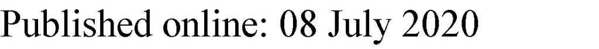

1.<sup>References</sup>

Stout KK, Broberg CS, Book WM, Cecchin F, Chen JM, Dimopoulos K, et al.

Chronic heart failure in congenital heart disease: a scientific statement from

the American Heart Association. Circulation. 2016;133(8):770–801..

2.

Chamsi-Pasha M, Chamsi-Pasha H. Critical congenital heart disease

screening. Avicenna J Med. 2016;6(3):65.

3.

Oster ME, Lee KA, Honein MA, Riehle-Colarusso T, Correa A. Temporal trends

in survival among infants with critical congenital heart defects HHS public

access. Pediatrics. 2013;131(5):1502–8.

4.

Lalu MM, Mazzarello S, Zlepnig J, Dong YY (Ryan), Montroy J, McIntyre L,

et al. Safety and efficacy of adult stem cell therapy for acute myocardial

infarction and ischemic heart failure (SafeCell Heart): a systematic review

and meta-analysis. Stem Cells Transl Med 2018;7(12):857–866.

5.

Fan M, Huang Y, Chen Z, Xia Y, Chen A, Lu D, et al. Efficacy of mesenchymal

stem cell therapy in systolic heart failure: a systematic review and meta-

analysis. Stem Cell Res Ther. 2019;10(1):1–14.

6.

Rong S-L, Wang Z-K, Zhou X-D, Wang X-L, Yang Z-M, Li B. Efficacy and

safety of stem cell therapy in patients with dilated cardiomyopathy: a

systematic appraisal and meta-analysis. J Transl Med. 2019;17(1):1–14.

7.

Kanelidis AJ, Premer C, Lopez J, Balkan W, Hare JM. Route of delivery

modulates the efficacy of mesenchymal stem cell therapy for myocardial

infarction: a meta-analysis of preclinical studies and clinical trials. Circ Res.

2017;120(7):1139–50.

8.

Tsilimigras DI, Oikonomou EK, Moris D, Schizas D, Economopoulos KP,

Mylonas KS. Stem cell therapy for congenital heart disease: a systematic

review. Circulation. 2017;24:2373–85 Lippincott Williams &

WilkinsHagerstown, MD.

9.

Wehman B, Kaushal S. The emergence of stem cell therapy for patients with

congenital heart disease. Circ Res. 2015;116(4):566–9.

10.

Agarwal U, Smith AW, French KM, Boopathy AV, George A, Trac D, et al.

Age-dependent effect of pediatric cardiac progenitor cells after juvenile

heart failure. Stem Cells Transl Med. 2016;5(7):883–92.

11.

Albertario A, Swim MM, Ahmed EM, Iacobazzi D, Yeong M, Madeddu P,

et al. Successful reconstruction of the right ventricular outflow tract by

implantation of thymus stem cell engineered graft in growing swine. JACC

Basic to Transl Sci. 2019;4(3):364–84.

12.

Brizard CP, Looi JYJ, Smolich JJ, Horton SB, Angerosa J, Elwood NJ, et al.

Safety of intracoronary human cord blood stem cells in a lamb model of

infant cardiopulmonary bypass. Ann Thorac Surg. 2015;100(3):1021–9.

13.

Davies B, Elwood NJ, Li S, Cullinane F, Edwards GA, Newgreen DF, et al. Human

cord blood stem cells enhance neonatal right ventricular function in an ovine

model of right ventricular training. Ann Thorac Surg. 2010;89(2):585–93 e4.

14.

Nana-Leventaki E, Nana M, Poulianitis N, Sampaziotis D, Perrea D, Sanoudou

D, et al. Cardiosphere-derived cells attenuate inflammation, preserve systolic

function, and prevent adverse remodeling in rat hearts with experimental

autoimmune myocarditis. J Cardiovasc Pharmacol Ther. 2019;24(1):70–7.

15.

Wolter KM. Introduction to variance estimation. 2nd ed. USA: Springer-

Verlag New York; 2007. p. 448.

16.

Mathias Harrer DE. Doing meta-analysis in R: a hands-on guide; 2019.

17.

Hooijmans CR, Rovers MM, RBM DV, Leenaars M, Ritskes-Hoitinga M,

Langendam MW. SYRCLE’s risk of bias tool for animal studies. BMC Med Res

Methodol. 2014;14(43):1–9.

18.

Sterne JA, Hernán MA, Reeves BC, Savović J, Berkman ND, Viswanathan M,

et al. ROBINS-I: a tool for assessing risk of bias in non-randomised studies of

interventions. BMJ. 2016;355(4919):1–7.

19.

McGuinness LA. robvis: an R package and web application for visualising

risk-of-bias assessments; 2019.

20.

Moher D, Liberati A, Tetzlaff J, Altman DG, Altman D, Antes G, et al.

Preferred reporting items for systematic reviews and meta-analyses: the

PRISMA statement. PLoS Med. 2009;6(7):272–97.

21.

Burkhart HM, Qureshi MY, Peral SC, O’Leary PW, Olson TM, Cetta F, et al.

Regenerative therapy for hypoplastic left heart syndrome: first report of

intraoperative intramyocardial injection of autologous umbilical-cord blood-

derived cells. J Thorac Cardiovasc Surg. 2015;149(3):e35–7.

22.

Burkhart HM, Qureshi MY, Rossano JW, Cantero Peral S, O’Leary PW,

Hathcock M, et al. Autologous stem cell therapy for hypoplastic left heart

syndrome: safety and feasibility of intraoperative intramyocardial injections.

J Thorac Cardiovasc Surg. 2019;158(6):1614–23.

23.

Eitoku T, Baba K, Kondou M, Kurita Y, Fukushima Y, Hirai K, et al.

Transcoronary cell infusion with the stop-flow technique in children with

single-ventricle physiology. Pediatr Int. 2018;60(3):240–6.

24.

Ishigami S, Ohtsuki S, Eitoku T, Ousaka D, Kondo M, Kurita Y, et al.

Intracoronary cardiac progenitor cells in single ventricle physiology: the

perseus (cardiac progenitor cell infusion to treat univentricular heart

disease) randomized phase 2 trial. Circ Res. 2017;120(7):1162–73.

25.

Pincott ES, Ridout D, Brocklesby M, McEwan A, Muthurangu V, Burch M. A

randomized study of autologous bone marrow–derived stem cells in

pediatric cardiomyopathy. J Hear Lung Transplant. 2017;36(8):837–44.

26.

Qureshi MY, Cabalka AK, Khan SP, Hagler DJ, Haile DT, Cannon BC, et al. Cell-

based therapy for myocardial dysfunction after Fontan operation in hypoplastic

left heart syndrome. Mayo Clin Proc Innov Qual Outcomes. 2017;1(2):185–91.

27.

Rivas J, Menéndez JJ, Arrieta R, Alves J, Romero MP, García-Guereta L, et al.

Utilidad de la terapia intracoronaria con células progenitoras en pacientes

con miocardiopatía dilatada: ¿Puente o alternativa al trasplante cardiaco? An

Pediatr. 2011;74(4):218–25.

28.

Rupp S, Zeiher AM, Dimmeler S, Tonn T, Bauer J, Jux C, et al. A regenerative

strategy for heart failure in hypoplastic left heart syndrome: intracoronary

administration of autologous bone marrow-derived progenitor cells. J Hear

Lung Transplant. 2010;29(5):574–7.

29.

Rupp S, Jux C, Bönig H, Bauer J, Tonn T, Seifried E, et al. Intracoronary bone

marrow cell application for terminal heart failure in children. Cardiol Young.

2012;22(5):558–63.

30.

Sano T, Ousaka D, Goto T, Ishigami S, Hirai K, Kasahara S, et al. Impact of

cardiac progenitor cells on heart failure and survival in single ventricle

congenital heart disease. Circ Res. 2018;122(7):994–1005.

31.

Tarui S, Ishigami S, Ousaka D, Kasahara S, Ohtsuki S, Sano S, et al.

Transcoronary infusion of cardiac progenitor cells in hypoplastic left heart

syndrome: three-year follow-up of the transcoronary infusion of cardiac

progenitor cells in patients with single-ventricle physiology (TICAP) trial. J

Thorac Cardiovasc Surg. 2015;150(5):1198–208 e2.

32.

Zschirnt M, Jux C, Boenig H, Zeiher A, Assmus B, Khalil M, et al. Neonatal

myocardial infarction: substantial improvement of cardiac function after

autologous bone marrow-derived cell therapy. Clin Res Cardiol. 2019:2–4.

33.

Ishigami S, Ohtsuki S, Tarui S, Ousaka D, Eitoku T, Kondo M, et al.

Intracoronary autologous cardiac progenitor cell transfer in patients with

Martinez et al. Stem Cell Research & Therapy (2020) 11:272

Page 12 of 13

hypoplastic left heart syndrome: the TICAP prospective phase 1 controlled

trial. Circ Res. 2015;116(4):653–64.

34.

Trac D, Maxwell JT, Brown ME, Xu C, Davis ME. Aggregation of child cardiac

progenitor cells into spheres activates notch signaling and improves

treatment of right ventricular heart failure. Circ Res. 2019;124(4):526–38.

35.

Hu X, Wang J, Chen J, Luo R, He A, Xie X, et al. Optimal temporal delivery of

bone marrow mesenchymal stem cells in rats with myocardial infarction.

Eur J Cardio-thoracic Surg. 2007;31(3):438–43.

36.

Crisostomo V, Baez-Diaz C, Maestre J, Garcia-Lindo M, Sun F, Casado JG,

et al. Delayed administration of allogeneic cardiac stem cell therapy for

acute myocardial infarction could ameliorate adverse remodeling:

experimental study in swine. J Transl Med. 2015;13(156):1–16.

37.

Xu JY, Liu D, Zhong Y, Huang RC. Effects of timing on intracoronary

autologous bone marrow-derived cell transplantation in acute myocardial

infarction: a meta-analysis of randomized controlled trials. Stem Cell Res

Ther. 2017;8(231):1–13.

38.

Nitkin CR, Bonfield TL. Concise review: mesenchymal stem cell therapy for

pediatric disease: perspectives on success and potential improvements.

Stem Cells Transl Med. 2017;6(2):539–65.

39.

Brunskill SJ, Hyde CJ, Doree CJ, Watt SM, Martin-Rendon E. Route of delivery

and baseline left ventricular ejection fraction, key factors of bone-marrow-

derived cell therapy for ischaemic heart disease. Eur J Heart Fail. 2009;11(9):

887–96.

40.

Wang WE, HS CX. Potential of cardiac stem/progenitor cells and induced

pluripotent stem cells for cardiac repair in ischaemic heart disease. Clini Sci.

2013;125(7):319–27.

41.

Zwetsloot PP, AMD V, Jansen Of Lorkeers SJ, GPJ VH, Currie GL, Sena ES,

et al. Cardiac stem cell treatment in myocardial infarction: a systematic

review and meta-analysis of preclinical studies. Circ Res. 2016.

42.

Fernández-Avilés F, Sanz-Ruiz R, Bogaert J, Plasencia AC, Gilaberte I, Belmans

A, et al. Safety and efficacy of intracoronary infusion of allogeneic human

cardiac stem cells in patients with st-segment elevation myocardial

infarction and left ventricular dysfunction a multicenter randomized,

double-blind, and placebo-controlled clinical trial. Circ Res. 2018;23(5):579–

89.

43.

Tang XL, Rokosh G, Sanganalmath SK, Tokita Y, MCL K, Shirk G, et al. Effects

of intracoronary infusion of escalating doses of cardiac stem cells in rats

with acute myocardial infarction. Circ Hear Fail. 2015.

44.

TIG VDS, Jansen Of Lorkeers SJ, Agostoni P, Van Belle E, Gyongyosi M, JPG S,

et al. Human relevance of pre-clinical studies in stem cell therapy:

systematic review and meta-analysis of large animal models of ischaemic

heart disease. Cardiovasc Res. 2011;91(4):649–58.

45.

Kemp CD, Conte JV. The pathophysiology of heart failure. Cardiovasc Pathol.

2012;21:365–71 Elsevier.

46.

Friedberg MK, Reddy S. Right ventricular failure in congenital heart disease.

Curr Opin Pediatr. 2019;31(5):604–10.

47.

Thompson M, Mei SHJ, Wolfe D, Champagne J, Fergusson D, Stewart DJ,

et al. Cell therapy with intravascular administration of mesenchymal stromal

cells continues to appear safe: an updated systematic review and meta-

analysis. EClinicalMedicine. 2020;19(100249):1–17.

48.

Chamuleau SAJ, Van Der Naald M, Climent AM, Kraaijeveld AO, Wever KE,

Duncker DJ, et al. Translational research in cardiovascular repair a call for a

paradigm shift. Circ Res. 2018;122(2):310–8.

Publisher’s Note

Springer Nature remains neutral with regard to jurisdictional claims in

published maps and institutional affiliations.

Martinez et al. Stem Cell Research & Therapy (2020) 11:272

Page 13 of 13